# Group Sequential Design Under Non-Proportional Hazards

December 6, 2021

## Welcome

## Outline

- 3:30: Introduction and background theory (30 minutes)
- 4:00: Proportional hazards applications with Shiny app (25 minutes)
- 4:25: Intro to non-proportional hazards (NPH; 5 minutes)
- 4:30: Software and piecewise model (15 min)
- 4:45: Average hazard ratio (AHR; 20 minutes)
- 5:05: Break (10 minutes)
- 5:15: NPH design with logrank test (25 minutes)
- 5:40: Weighted logrank and combination tests (40 minutes)
- 6:20 Summary and questions (10 minutes)

## Disclaimer

- All opinions expressed are those of the presenters and not Merck Sharp & Dohme Corp., a subsidiary of Merck & Co., Inc., Kenilworth, NJ, USA.
- Some slides need to be scrolled down to see the full content.

## Software

For minimum effort and maximum benefit, you will probably at least want to use the Shiny interface for the **gsDesign** R package at https://rinpharma.shinyapps.io/gsdesign/. This is also available at https://gsdesign.shinyapps.io/prod/, but this site is only licensed for a small number of simultaneous users.

## Course resources

- Book at https://keaven.github.io/gsd-deming/
  - Instructions there to install software, download repository at https://github.com/keaven/gsd-deming
  - Directories there we will use:
    - `data/`: contains design files for examples; also simulation results
    - `vignettes/`: reports produced by Shiny app to summarize designs
    - `simulation/`: R code and simulation data for the last part of course

## Background

## Group sequential design

- Analyze a trial repeatedly at planned intervals
- Group of data added at each analysis
- Group sequential design derives boundaries and sample size to
  - Control Type I error
  - Ensure power
  - Stop early for futility or efficacy finding
- Takes advantage of correlated, group sequential tests

## Independent increments process - group sequential design

- Asymptotic normal assumption works well for most trials
- Scharfstein et al (1997) demonstrated \(Z = (Z_1, \dots, Z_K)\) is asymptotically normal with independent increments.
- We extend the canonical distribution notation of Jennison and Turnbull (2000):
  - \(Z_k\) is test statistics for treatment effect at analysis \(k=1,\ldots,K\)
  - \((Z_1,\ldots,Z_K)\) is multivariate normal
  - \(E(Z_k) = \theta_k \sqrt{I_k}, k=1,\ldots,K\)
  - \(\hbox{Cov}(Z_{k_1}, Z_{k_2})=\sqrt{I_{k_1}/I_{k_2}},\) \(1\le k_1\le k_2\le K\)
- \(I_k\) is the Fisher information for \(\theta_k, k=1,\ldots, K\).
- For most of this training \(\theta_k=-E(\log(HR_k))\)
- Simulation can be used to examine accuracy of normal approximation

## Assumptions for time-to-event endpoints

- Lachin and Foulkes (1986) piecewise model used to approximate arbitrary enrollment, survival, dropout patterns
  - Fixed enrollment and follow-up period
    - increase enrollment rates to obtain power
  - Proportional hazards: \(\theta_k=\theta\) (constant)
  - \(I_k\) ~proportional to event count Schoenfeld (1981)
- We generalize to average hazard ratio (AHR; Mukhopadhyay et al (2020)) for non-proportional hazards (NPH) tested with logrank (\(\theta_k\) varies with \(k\))
- Generalized to cover weighted logrank as in Yung and Liu (2020) in final section today
  - Fixed design only for RMST
  - Combination tests with multiple weighted logrank tests have more complex correlation structure (Karrison and others (2016))

## Testing bounds

- Bounds \(-\infty \le a_k \le b_k \le \infty\) for \(k=1,\dots,K\)
- Null hypothesis \(H_0:\) \(\theta_k=0, k=1,\ldots,K\)
- Alternate hypothesis \(H_1:\) \(\theta_k > 0\) for some \(k=1,\ldots,K\)
- Actions at analysis \(k=1,\ldots,K\):
  - Reject \(H_0\) at analysis \(k\) if \(Z_k\ge b_k\)
  - Do not reject \(H_0\) and consider stopping if \(Z_k<a_k\), \(k<K\)
  - Continue trial if \(a_k\le Z_k\le b_k\), \(k<K\)
- Bounds are generally considered advisory for stopping trial, not binding

## Boundary crossing probabilities

- Upper boundary crossing probabilities
  - \(u_k(\theta) = \text{Pr}_\theta(\{Z_k \ge b_k\} \cap_{j=1}^{k-1} \{a_j \le Z_j < b_j\})\)
- Lower boundary crossing probabilities
  - \(l_k(\theta) = \text{Pr}_\theta (\{Z_k < a_k\} \cap_{j=1}^{k-1} \{a_j \le Z_j < b_j\})\)
- Null hypothesis: 1-sided Type I error
  - \(a_k = -\infty\) for all \(k\) generally used for Type I error
    - Non-binding lower bound
  - \(\alpha = \sum_{k=1}^{K} u_k(0) = \sum_{k=1}^{K} \text{Pr}(\{Z_k \ge b_k\} \cap_{j=1}^{k-1} \{a_j \le Z_j \le b_j\} \mid H_0)\)

## Boundary crossing probabilities (cont.)

- Alternate hypothesis: Type II error \(\beta= 1 - \hbox{power}\)

  \[-\infty\le a_k<b_k, k=1,\ldots,K-1,\] \[a_K\le b_K\] If \(a_K = b_K\) then total Type II error is \[\beta = \sum_{k=1}^{K} l_k = \sum_{k=1}^{K} \text{Pr}(\{Z_k < a_k\} \cap_{j=1}^{k-1} \{a_j \le Z_j \le b_j\}\mid H_1)\]

## Symmetric bounds

Test each treatment for superiority vs the other

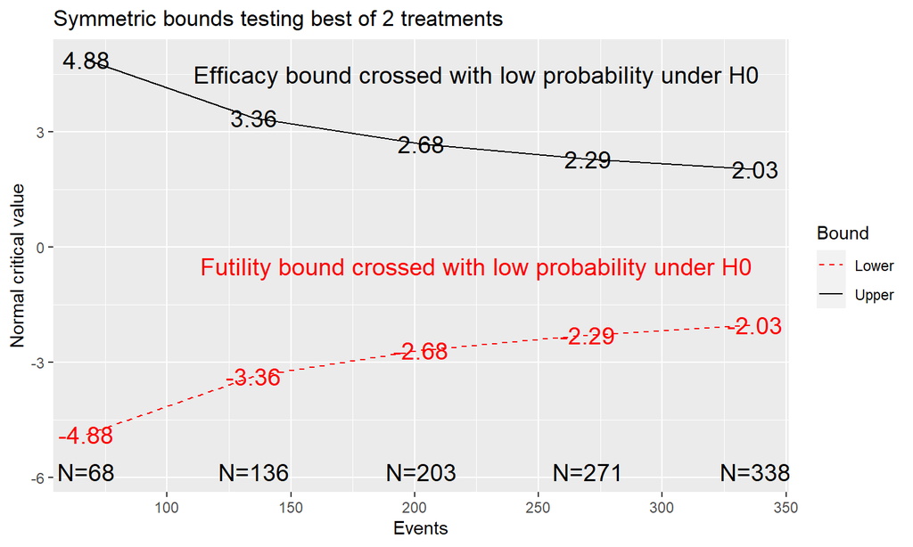

Usually not of interest in pharmaceutical industry

## Futility bounds

Give up if experimental arm not trending in favor of control?

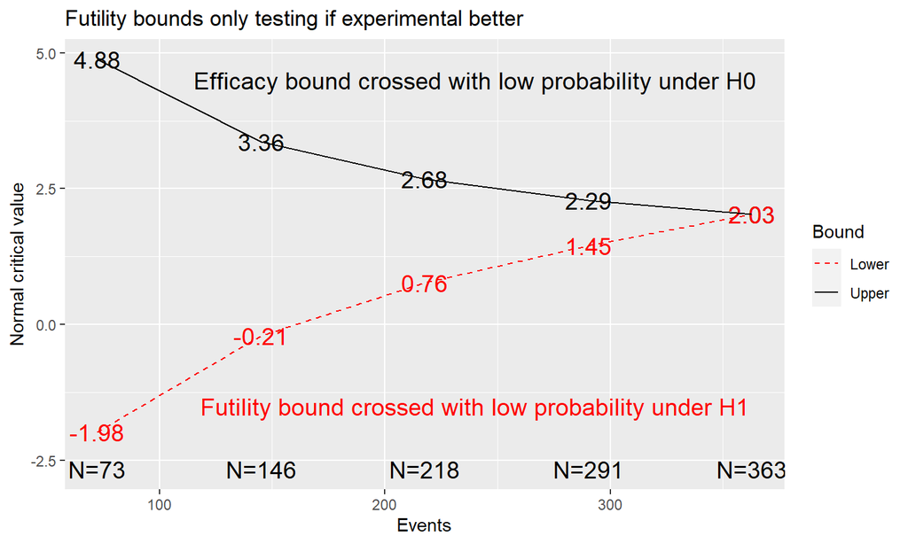

- Ethics of continuing trial if unlikely to show superiority?
- Excess risk of crossing lower bound too soon?

## Asymmetric 2-sided testing

Give up if experimental arm trending worse than control

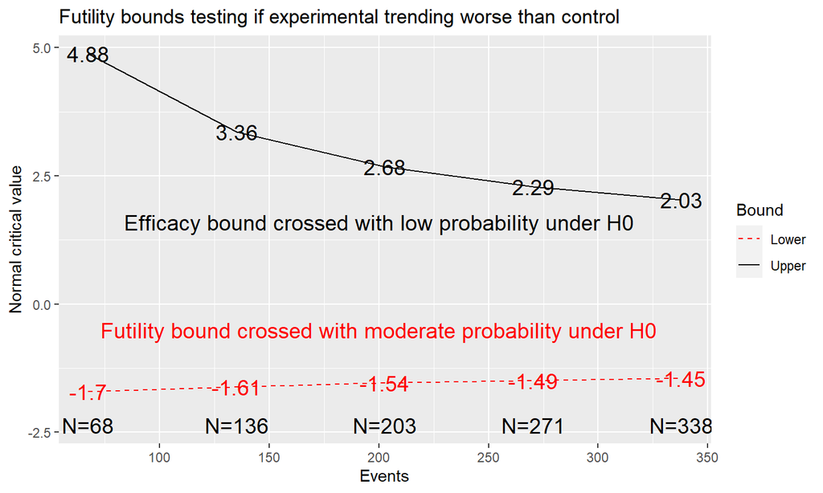

## Sample size

- Given boundary computation, sample size solves for enrollment rate
- Fixing relative enrollment rates, dropout rates and trial duration enable Lachin and Foulkes (1986) and our AHR methods
- Under proportional hazards, you can also fix max enrollment rate and solve for trial duration (Kim and Tsiatis 1990)
  - You can easily create scenarios here for which there is no solution
  - Error message *An error has occurred. Check your logs or contact the app author for clarification.*
  - Need to adjust parameters until a solution is found or use Lachin and Foulkes (1986)

## Boundary types

- **Approaches to calculate decision boundary:**
  - The error spending approach: specify boundary **crossing probabilities** at each analysis. This is most commonly done with the **error spending function** approach (Lan and DeMets 1983).
  - The boundary family approach: specify how big boundary values should be **relative** to each other and adjust these relative values by **a constant multiple to control overall error rates**. The commonly applied boundary family include:
    - Haybittle-Peto boundary (Haybittle (1971), Peto et al (1977))
    - Wang-Tsiatis boundary (Wang and Tsiatis 1987)
      - Pocock boundary (Pocock 1977)
      - O’Brien and Fleming boundary (O’Brien and Fleming 1979)
    - Slud and Wei (1982) and Fleming et al (1984) set fixed IA boundary crossing probabilities
      - Hybrid of boundary family/spending approach

## Boundary families

## Boundary family - Haybittle-Peto boundary

- **Main idea:**
  - Interim Z-score boundary: 3
  - Final Z-score boundary: 1.96 (slight \(\alpha\) inflation)

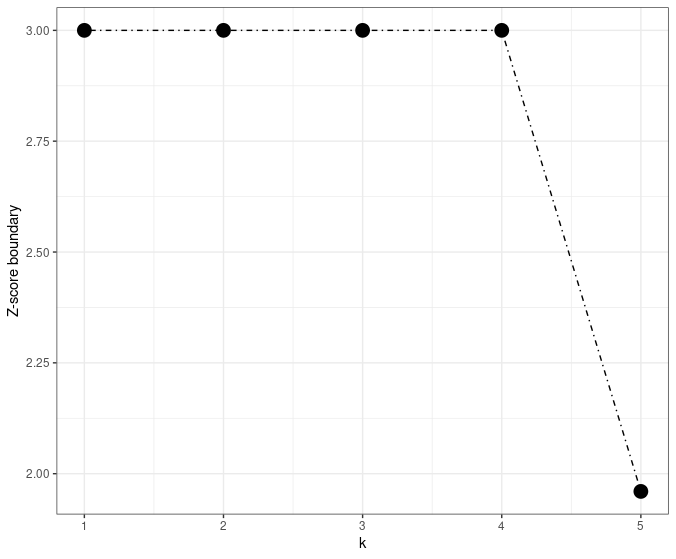

## Boundary family - Wang-Tsiatis bounds

- **Definition:**

  For 2-sided testing, Wang and Tsiatis (1987) defined the boundary function for the \(k\)-th look as \[ \Gamma(\alpha, K, \Delta) k^{\Delta - 0.5}, \] where \(\Gamma(\alpha, K, \Delta)\) is a constant chosen so that the level of significance is equal to \(\alpha\).
- **Two special cases:**
  - \(\Delta = 0.5\): Pocock bounds
  - \(\Delta = 0\): O’Brien-Fleming bounds.

## Wang-Tsiatis example - Pocock boundary

For 2-sided testing, the Pocock procedure rejects at the \(k\)-th equally-spaced of \(K\) looks if \[|Z_k| > c_P(K),\] where \(c_P(K)\) is fixed given \(K\) such that \(\text{Pr}(\cup_{k=1}^{K} |Z_k| > c_P(K)) = \alpha\).

## Wang-Tsiatis example - Pocock boundary (cont’d)

- **Example:**

| total number of looks(K) | \(\alpha = 0.01\) | \(\alpha = 0.05\) | \(\alpha = 0.1\) |
| --- | --- | --- | --- |
| 1 | 2.576 | 1.960 | 1.645 |
| 2 | 2.772 | 2.178 | 1.875 |
| 4 | 2.939 | **2.361** | 2.067 |
| 8 | 3.078 | 2.512 | 2.225 |
| \(\infty\) | \(\infty\) | \(\infty\) | \(\infty\) |

We will reject \(H_0\) if \(|Z(k/4)| > 2.361\) for \(k = 1,2,3,4\) (final analysis).

- **Weakness:**
  - Overly aggressive interim bounds
  - High price for the end of the trial.
    - With \(\alpha = 0.05\) and 4 analyses (\(k=4\)), the absolute value of z-score would have to exceed 2.361 to be declared significant, including the final analysis (normally 1.96).
    - Z=2.361 translates to a two-tailed “nominal p-value”: \(2(1 − \Phi(2.361))\) = 0.018.
  - \(c_P(K) \to +\infty\) as \(K \to + \infty\).
  - Requires equally spaced looks.

## Wang-Tsiatis example - O’Brien-Fleming boundary

- Early stage: very conservative \(\Rightarrow\) large boundary at the begining;
- Final stage: nominal value close to the overall value of the design \(\Rightarrow \approx 1.96\).
- Regulators generally like these bounds

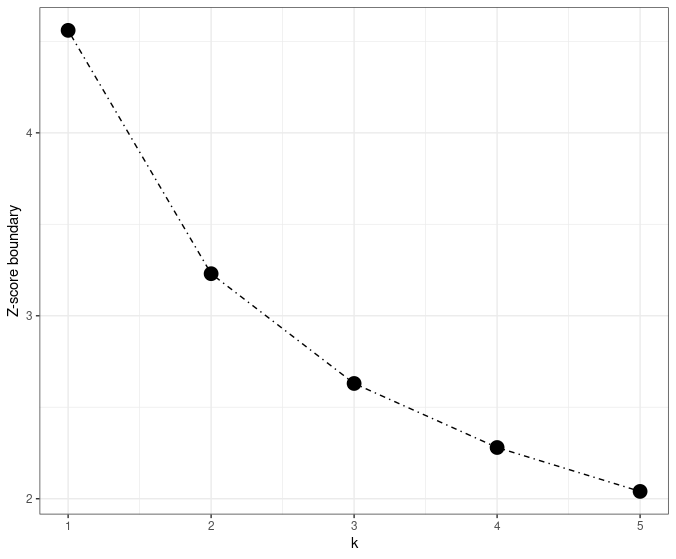

## Wang-Tsiatis example - O’Brien-Fleming boundary (cont’d)

| total number of looks(K) | \(\alpha = 0.01\) | \(\alpha = 0.05\) | \(\alpha = 0.1\) |
| --- | --- | --- | --- |
| 1 | 2.576 | 1.960 | 1.645 |
| 2 | 2.580 | 1.977 | 1.678 |
| 4 | 2.609 | **2.024** | 1.733 |
| 8 | 2.648 | 2.072 | 1.786 |
| 16 | 2.684 | 2.114 | 1.830 |
| \(\infty\) | 2.807 | 2.241 | 1.960 |

**Example:**

- The tabled value 2.024 is the flat B-value boundary.
- The flat B-value boundary can be easily transformed into decreasing Z-score boundary by \(Z(t) = B(t)/\sqrt{t}\):
  - \(2.024/\sqrt{1/4} = 4.05\)
  - \(2.024/\sqrt{2/4} = 2.86\)
  - \(2.024/\sqrt{3/4} = 2.34\)
  - \(2.024/\sqrt{4/4} = 2.02\)

## Boundary families - summary

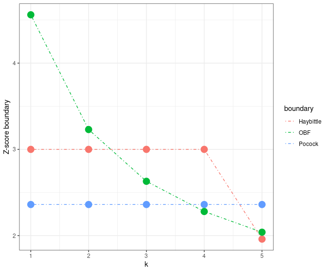

## Boundary families - summary (cont’d)

[output not shown]

## Spending function boundaries

## Spending function

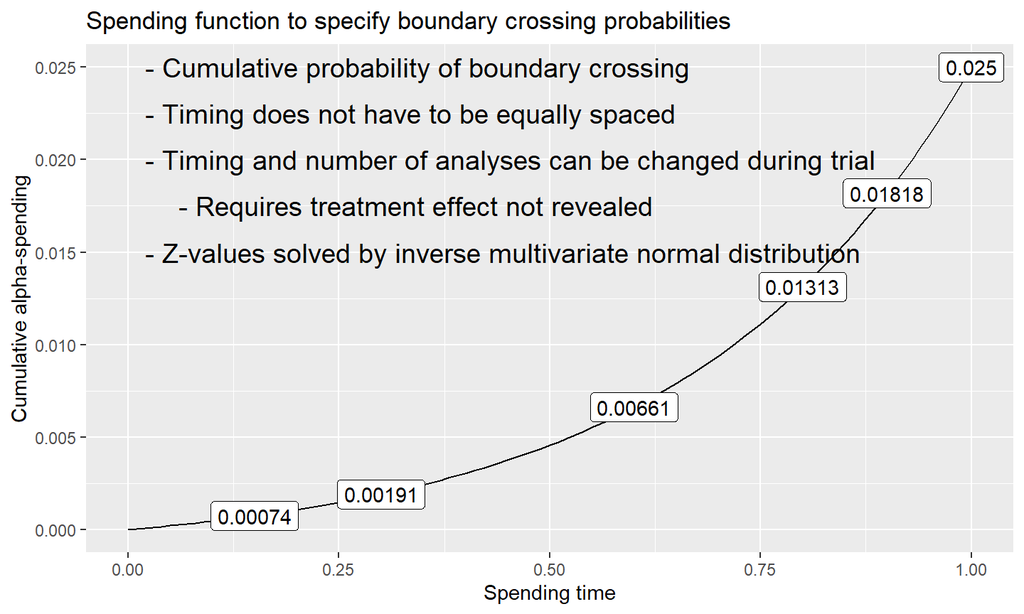

## Lan-DeMets spending functions to approximate boundary families

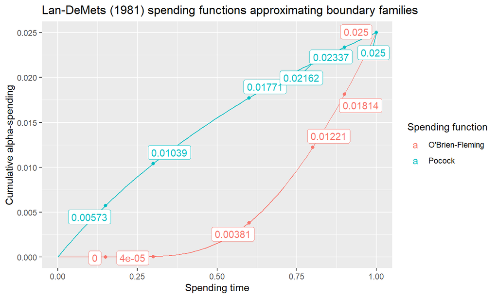

## Hwang-Shih-DeCani (gamma) spending functions

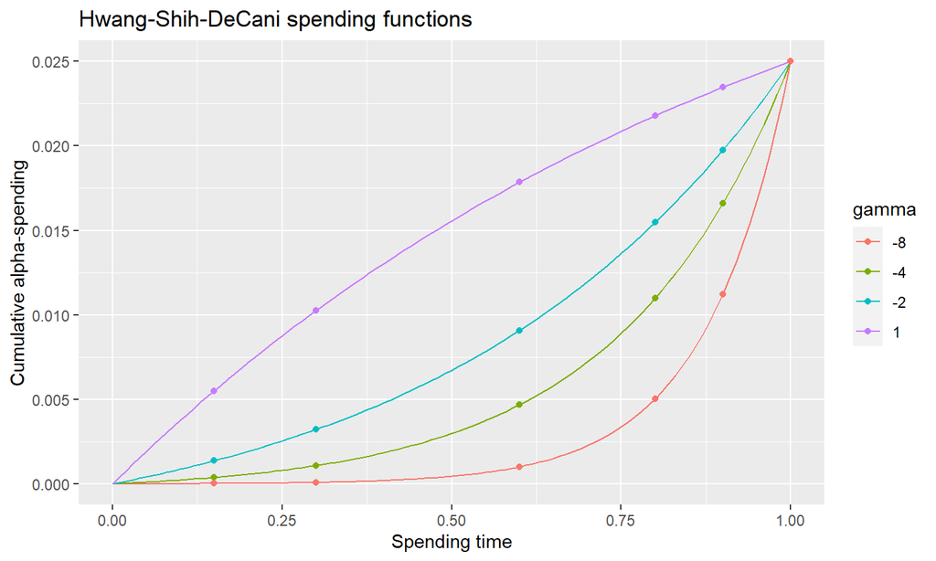

## What is spending time?

- Information fraction, Lan and DeMets (1983)
  - Time-to-event: fraction of planned final events in analysis
  - Normal or binomial: fraction of planned final sample size in analysis
  - Usually expected by regulators
- Calendar fraction, Lan and DeMets (1989)
  - Fraction of trial planned calendar duration at analysis
- Minimum of planned and actual information fraction
  - Probably not advised yet

## General methods and proportional hazards

## Proportional hazards approach

## Lachin and Foulkes (1986) method

- Sample size and power derivation
- Time-to-event endpoint
- 2-arm trial
- Logrank (or Cox model coefficient) to test treatment effect
- Constant treatment effect over time (proportional hazards or PH)
- Number of events drives power, regardless of study duration

## Shiny app for proportional hazards

- Shiny app available at:
  - https://rinpharma.shinyapps.io/gsdesign/ (preferred)
  - https://gsdesign.shinyapps.io/prod/ (not preferred)
  - [Video intro](https://www.youtube.com/watch?v=8uZRuvzma9)
- Allows broad specification of designs
- Much simpler than writing code
- It will write code and reports for you
- Saves and re-loads designs
- Some flexibility of **gsDesign** not in app to simplify interface

## Metastatic oncology example

- KEYNOTE 189 trial (Gandhi et al (2018))
  - Endpoints: progression free survival (PFS) and overall survival (OS) in patients
  - Indication: previously untreated metastatic non-small cell lung cancer (NSCLC)
  - Treatments: chemotherapy +/- pembrolizumab
  - Randomized 2:1 to an add-on of pembrolizumab or placebo
  - Type I error (1-sided): 0.025 familywise error rate (FWER) split between PFS (\(\alpha=0.0095\)) and OS (\(\alpha=0.0155\))
  - Graphical method \(\alpha\)-control for group sequential design of Maurer and Bretz (2013) used

## Metastatic oncology: OS design approximation (continued)

- \(\alpha=0.0155\)
- Control group survival: exponential median=13 months
- Exponential dropout rate of 0.133% per month
- 90% power to detect a hazard ratio (HR) of 0.70025
- 2:1 randomization, experimental:control
- Enrollment over 1 year
- While not specified in the protocol, we have further assumed:
  - Trial duration: 35 months.
  - Observed deaths of 240, 332 and 416 at the 3 planned analyses
  - A one-sided bound using the Lan and DeMets (1983) spending approximating an O’Brien-Fleming bound.

## Cardiovascular outcomes reduction

- AFCAPS/TEXCAPS trial: use of lovastatin to reduce cardiovascular outcomes
- Design described in Downs et al (1997)
- Results reported in Downs et al (1998)
- Reproduction here not exact mainly due to choice of Lachin and Foulkes (1986)
  - Little difference between methods
  - Efficacy bounds will be exactly as proposed

## Cardiovascular outcomes: key parameters

- 5 years minimum follow-up of all patients enrolled
- Interim analyses after 0.375 and 0.75 of final planned event count has accrued
- 2-sided bound using the Hwang et al (1990) spending function with parameter \(\gamma = -4\) to approximate an O’Brien-Fleming bound
- We arbitrarily set the following parameters to match design:
  - Power of 90% for a hazard ratio of 0.6921846; this is slightly different than the 0.7 hazard ratio suggested in Downs et al (1997)
  - Enrollment duration of 1/2 year with constant enrollment.
  - An exponential failure rate of 0.01131 per year which is nearly identical to the annual failure rate of 0.01125.
  - An exponential dropout rate of 0.004 per year which is nearly identical to the annual dropout rate of 0.00399.

## Cardiovascular outcomes non-inferiority: EXAMINE trial

- Indication: treatment of diabetes
- Treatments: DPP4 inhibitor alogliptin compared to placebo
- Primary endpoint: major cardiovascular outcomes (MACE)
- Objective: establish non-inferiority
- Results in White et al (2013)
- Design in White et al (2011)
- We approximate the design and primary analysis evaluation here.
- Software and design assumptions not completely clear; not exact design reproduction

## EXAMINE trial: Key assumptions

- Primary analysis: stratified Cox model for MACE
  - 1-sided repeated confidence interval for HR at each analysis.
  - Analysis to rule out HR > 1.3, but also tests superiority.
  - Analyses planned after 550, 600, 650 MACE events.
  - O’Brien-Fleming-like spending function Lan and DeMets (1983).
  - 2.5% Type I error.
  - Approximately 91% power.
  - 3.5% annual MACE event rate.
  - Uniform enrollment over 2 years.
  - 4.75 years trial duration.
  - 1% annual loss-to-follow-up rate.
  - Software: EAST 5 (Cytel).

## Cure model

Poisson mixture cure model we consider:

\[S(t)= \exp(-\theta (1 - \exp(-\lambda t)).\]

Note that:

- \(1-\exp(-\lambda t)\) is the CDF for an exponential distribution
  - can be replaced by arbitrary continuous CDF.
- As \(t\rightarrow \infty\), \(S(t)\rightarrow\exp(-\theta)\) (cure rate).
- Model useful when historical data suggests plateau in survival.
- PH model: experimental survival \(S_E(t)=S_C(t)^{HR}\).

## Survival model assumptions

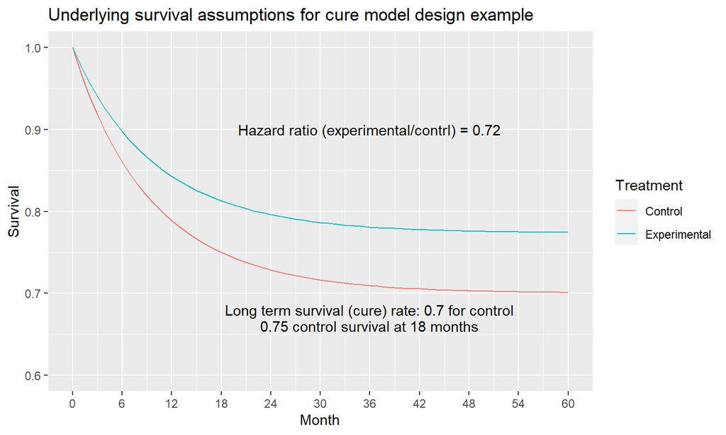

More details in book.

## Cure model: Expected event accumulation over time

- Event accumulation over time can be very sensitive to many trial design assumptions.
- Generally, we are trying to mimic a slowing of event accumulation over time.
- Assume 18 month enrollment with 6-month ramp-up.

## Expected event accrual over time

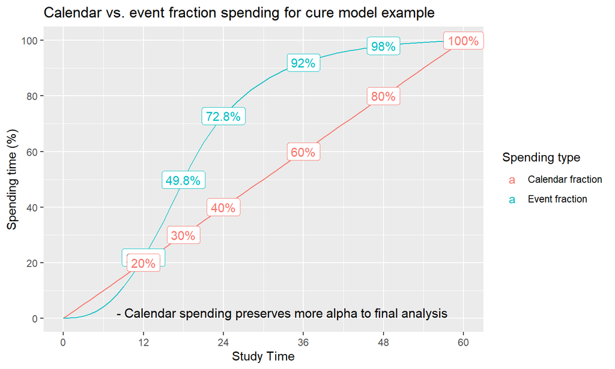

## Potential advantages/disadvantages of calendar spending

- Quite possible that event rate design assumptions incorrect
- Good to ensure duration of follow-up is adequate evaluate tail behavior/plateau in survival
- Ensures adequate follow-up to estimate relevant parts of survival curve
- Limits trial to relevant clinical and practical duration
- May be underpowered if events accrue slowly
- Probably less useful for high-risk endpoints (e.g., metastatic cancer)
- Regulatory resistance?

## Exercise

See the following link for the Moderna COVID-19 design replication: https://medium.com/@yipeng_39244/reverse-engineering-the-statistical-analyses-in-the-moderna-protocol-2c9fd7544326

Can you reproduce this using the Shiny interface?

## Average hazard ratio approach

## Delayed effect

- Recurrent head and neck squamous cell carcinoma
- Pembrolizumab vs Standard of Care (SOC)
- 1:1 randomization, N=495
- Primary endpoint: OS
- 90% power for HR=0.7, 1-sided \(\alpha=0.025\)
- Design (Am 11; [protocol](https://ars.els-cdn.com/content/image/1-s2.0-S0140673618319998-mmc1.pdf)) and results
  - Proceeded to final analysis (388 deaths; 340 planned)
    - 1-sided nominal p-value for OS: 0.0161
- 2 interim analyses planned (144 and 216 deaths; IF = 0.42, 0.64)
  - IF = information fraction
  - Efficacy: Hwang-Shih-DeCani (HSD) spending, \(\gamma=-4\)
  - Futility: non-binding, \(\beta\)-spending, HSD, \(\gamma = -16\)

KEYNOTE 040: Overall Survival

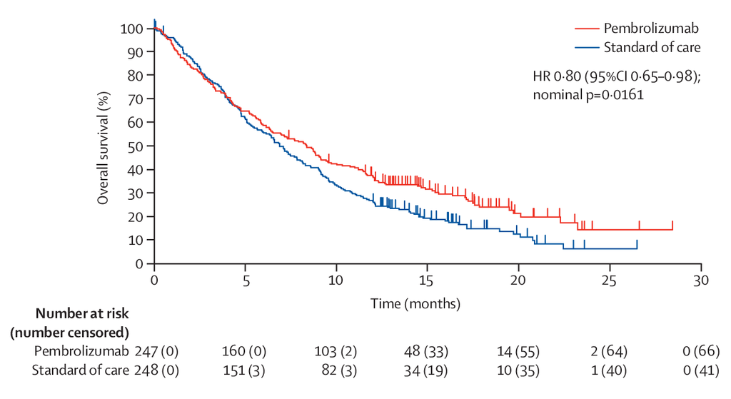

Cohen et al (2019)

## Delayed effect not just in oncology

Cholesterol lowering and mortality Miettinen et al (1997)

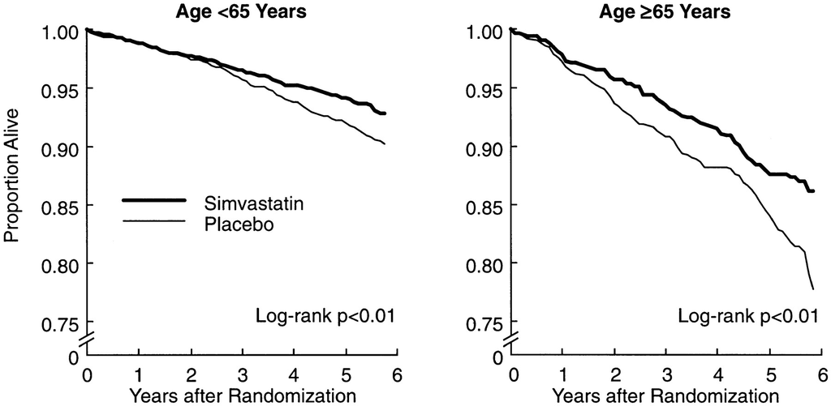

Scandinavian Simvistatin Survival Study

## Proportional hazards

- First line metastatic lung CA (NSCLC)
- Chemo + Pembrolizumab vs Chemo
- 2:1 randomization, N=616
- Primary endpoints
  - Progression free survival (PFS)
  - Overall survival (OS)
- Potential for delayed OS effect not realized
- Median follow-up: 10.5 months
- Design (Am 7; [protocol](https://www.nejm.org/doi/suppl/10.1056/NEJMoa1801005/suppl_file/nejmoa1801005_protocol.pdf))
- Stopped at first IA (235 deaths; IF = 0.56)
- Plan for final analysis: 416 deaths
- Adjusted 1-sided p-value for OS: 0.00559
- O’Brien-Fleming spending

KEYNOTE 189

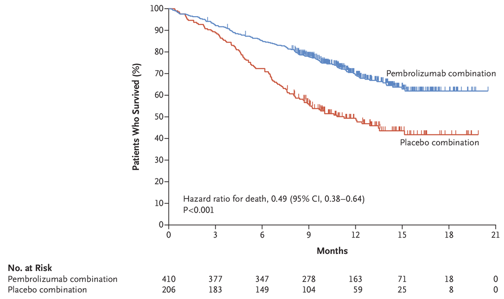

Gandhi et al (2018)

## Crossing survival curves

- Recurrent advanced gastric or gastro-oesophageal junction cancer
- Pembrolizumab vs Paclitaxel
- 1:1 randomization, N=360 planned (N=395 actual) in CPS \(\ge\) 1 population
- Primary endpoints:
  - OS in PD-L1 CPS \(\ge\) 1
    - 91% power for HR=0.67, 1-sided \(\alpha=0.0215\)
  - PFS in PD-L1 CPS \(\ge\) 1
- Design (Am 11; [protocol](https://ars.els-cdn.com/content/image/1-s2.0-S0140673618312571-mmc1.pdf)) and results in CPS \(\ge\) 1
  - Proceeded to final analysis (326 deaths; 290 planned)
  - 1 IA planned (240 deaths; IF = 0.83)
    - Efficacy: Hwang-Shih-DeCani (HSD) spending, \(\gamma=-4\)

KEYNOTE 061: Overall Survival in CPS 1

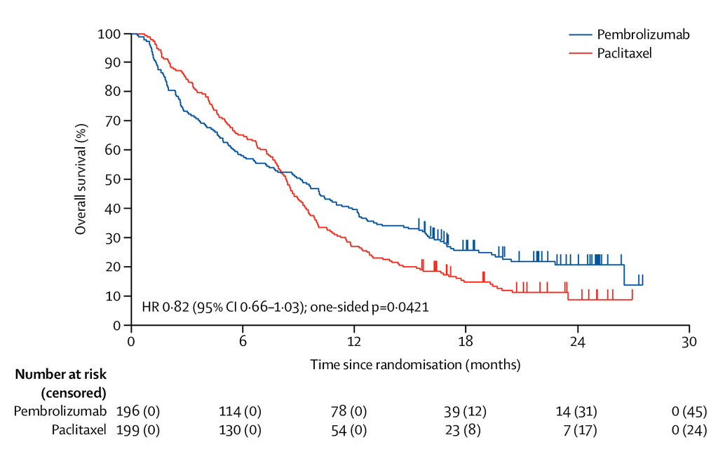

Shitara et al (2018)

- No futility bound
- 1-sided nominal p-value for OS: 0.0421 (threshold: p=0.0135)
- *Post hoc* FH(\(\rho=1,\gamma=1\)): p=0.0009

## Summary of issues

- What is the impact of (potentially) delayed treatment effect on trial design and analysis?
- Test statistics used (logrank for this section; next section suggests alternatives)
- Sample size vs duration of follow-up
- Timing of analyses
- Futility bounds
- Updating bounds
- Multiplicity adjustments

## Software installation

`simtrial`, `gsDesign2` and `gsdmvn` are under development and hosted on GitHub/Merck.

Below is the GitHub repo link to the source code

- `simtrial`: https://github.com/Merck/simtrial
- `gsDesign2`: https://github.com/Merck/gsDesign2
- `gsdmvn`: https://github.com/Merck/gsdmvn

How to report issues?

- Create issue under the GitHub repo listed above.

## simtrial overview

- Time-to-event trial simulation
- Piecewise model
- Logrank and weighted logrank analysis
- Simulating fixed and group sequential design
  - Also potential to simulate adaptive design
- Reverse engineered datasets from NPH Working Group
- Validation near completion
  - Thanks to AP colleagues and Amin Shirazi

## simtrial functions

- Generating simulated datasets
  - `simfix()`: Simulation of fixed sample size design for time-to-event endpoint
  - `simfix2simPWSurv()`: Conversion of enrollment and failure rates from `simfix()` to `simPWSurv()` format
  - `simPWSurv()`: Simulate a stratified time-to-event outcome randomized trial
- Cutting data for analysis
  - `cutData()`: Cut a dataset for analysis at a specified date
  - `cutDataAtCount()`: Cut a dataset for analysis at a specified event count
  - `getCutDateForCount()`: Get date at which an event count is reached
- Analysis functions
  - `tenFH()`: Fleming-Harrington weighted logrank tests
  - `tenFHcorr()`: Fleming-Harrington weighted logrank tests plus correlations
  - `tensurv()`: Process survival data into counting process format
  - `pMaxCombo()`: MaxCombo p-value
  - `pwexpfit()`: Piecewise exponential survival estimation
  - `wMB()`: Magirr and Burman modestly weighted logrank tests
- Lower level functions
  - `fixedBlockRand()`: Permuted fixed block randomization
  - `rpwenroll()`: Generate piecewise exponential enrollment
  - `rpwexp()`: The piecewise exponential distribution

## simtrial: reverse engineered datasets

From NPH Working Group

- `Ex1delayedEffect`: Time-to-event data example 1 for non-proportional hazards working group
- `Ex2delayedEffect`: Time-to-event data example 2 for non-proportional hazards working group
- `Ex3curewithph`: Time-to-event data example 3 for non-proportional hazards working group
- `Ex4belly`: Time-to-event data example 4 for non-proportional hazards working group
- `Ex5widening`: Time-to-event data example 5 for non-proportional hazards working group
- `Ex6crossing`: Time-to-event data example 6 for non-proportional hazards working group
- `MBdelayed`: Simulated survival dataset with delayed treatment effect

## gsDesign2

- `AHR()`: Average hazard ratio under non-proportional hazards (test version)
- `eAccrual()`: Piecewise constant expected accrual
- `eEvents_df()`: Expected events observed under piecewise exponential model
- `ppwe()`: Estimate piecewise exponential cumulative distribution function
- `s2pwe()`: Approximate survival distribution with piecewise exponential distribution
- `tEvents()`: Predict time at which a targeted event count is achieved

We will focus on `AHR()`, `ppwe()`, and `s2pwe()` in this training.

## gsdmvn

Power and design functions extending the Jennison and Turnbull (2000) computational model to non-constant treatment effects. Partial list of functions:

- Design and power under average hazard ratio model
  - `gs_power_ahr()`: Power computation
  - `gs_design_ahr()`: Design computations
- Bound support
  - `gs_b()`: direct input of bounds
  - `gs_spending_bound()`: spending function bounds
- Other tests
  - Design and power with weighted logrank and MaxCombo will be discussed in next section.

## The piecewise model

## Introducing the piecewise model

- Simple model to approximate arbitrary patterns of
  - Enrollment: piecewise constant enrollment rates
  - Failure rates: piecewise exponential
  - Dropout rates: piecewise exponential
- Combined tools for designing and evaluating designs
  - Asymptotic approach using average hazard ratio (AHR)
  - Simulation tools to confirm asymptotic approximations
  - No requirement for proportional hazards
  - Stick with logrank for this section

## Piecewise constant enrollment

Set up piecewise exponential enrollment rates

```r
enrollRates <- tibble::tribble(
  ~duration, ~rate,
  # 5/month for 6 months
  6, 5,
  # 20/month until enrollment complete
  6, 20
)
```

Get enrollment times for 150 observations

```r
set.seed(123)
Month <- simtrial::rpwenroll(
  n = 150,
  enrollRates = enrollRates
)
```

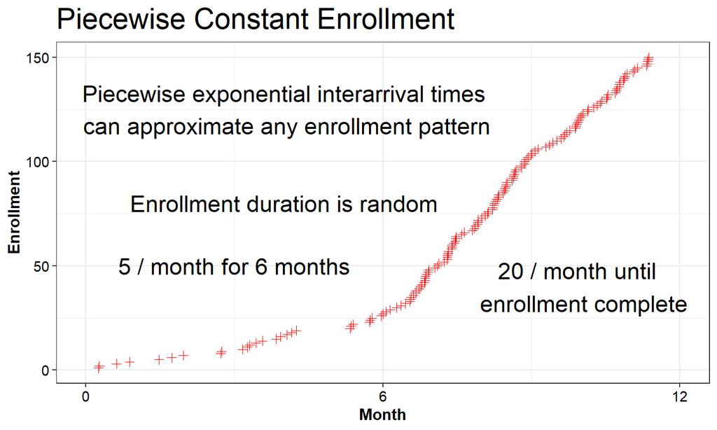

## Question

- Should we assume all enrollment
  - by targeted time?
  - *random, expected enrollment matches target at targeted time?*
- **simtrial** package assumes the latter
  - Also used in AHR approach here
- **npsurvSS** package assumes the former
  - Used for weighted logrank and combination tests in next section

## Failure rates

Note: under exponential distribution, median (\(m\)) and failure rate (\(\lambda\)) related:

\[ \begin{align} m=&\log(2)/\lambda \\ \lambda=&\log(2)/m \\ \end{align} \]

Specify failure rates and dropout rates in same table

```r
# Control: exponential with 15 month median
# HR: 1 for 4 months, 0.6 thereafter
failRates <- tibble::tribble(
  ~Stratum, ~duration, ~failRate, ~hr, ~dropoutRate,
  "All", 4, log(2) / 15, 1, .001,
  "All", 100, log(2) / 15, 0.6, .001
)
```

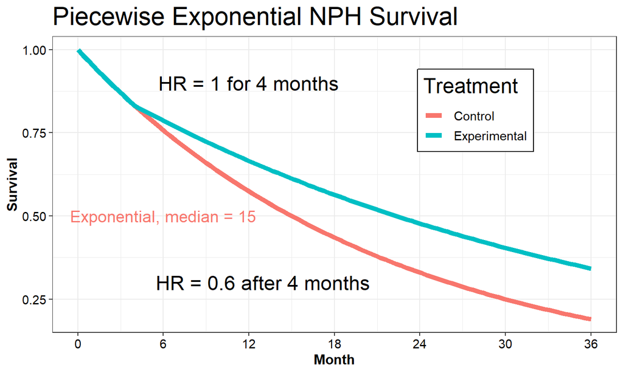

## Piecewise exponential approximation

```r
dloglogis <- function(x, alpha = 1, beta = 4) {
  1 / (1 + (x / alpha)^beta)
}
times10 <- c(seq(1 / 3, 1, 1 / 3), 2, 3)
# Use s2pwe() to generate piecewise approximation
gsDesign2::s2pwe(
  times = times10, survival =
    dloglogis(times10, alpha = .5, beta = 4)
) %>%
  gt() %>%
  fmt_number(col = 1:2, decimals=3)
```

| duration | rate |
| --- | --- |
| 0.333 | 0.541 |
| 0.333 | 3.736 |
| 0.333 | 4.223 |
| 1.000 | 2.716 |
| 1.000 | 1.619 |

- Approximating log-logistic distribution plotted above using piecewise model here
- Can approximate any survival distribution

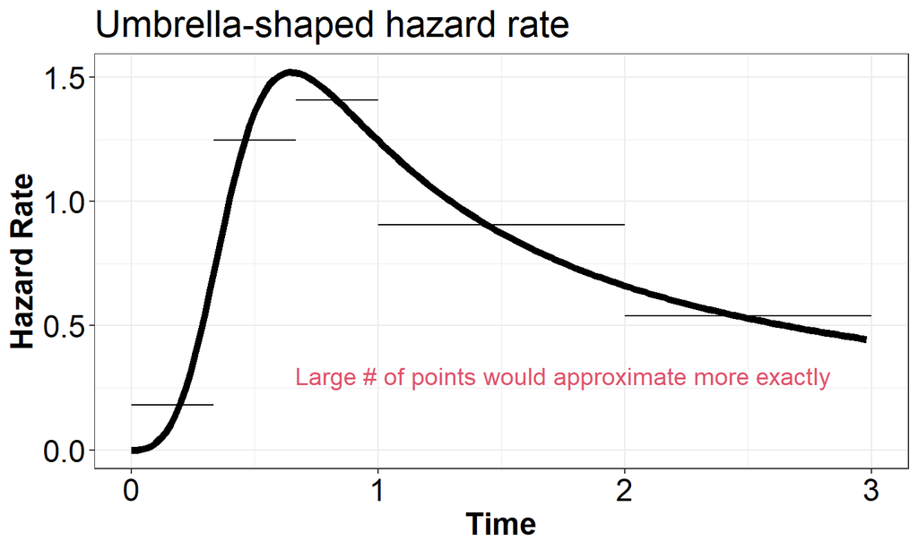

## Approximating using piecewise model

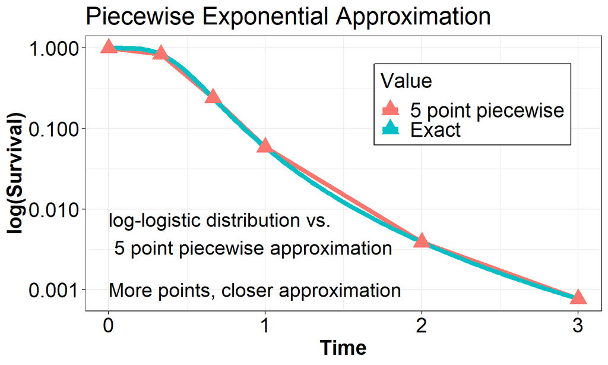

## Break (10 minutes)

## Average hazard ratio

## Overview

- Definition of average hazard ratio
- Literature review
- Asymptotic theory for group sequential design
- Verification by simulation

## Average hazard ratio (AHR)

- Geometric mean hazard ratio (Mukhopadhyay et al (2020))
- Exponentiate: average \(\log(\hbox{HR})\) weighted by expected events per interval

| Interval | HR | -ln(HR) | Expected Events |
| --- | --- | --- | --- |
| 0-4 | 1.0 | 0.00 | d1 |
| >4 | 0.6 | 0.51 | d2 |

\[\hbox{AHR} = \exp\left( \frac{d_1 \log(1) + d_2 \log(0.6)}{d_1 + d_2}\right)\]

## Approach to asymptotic theory

- Assume \((t_{m-1},t_m]\) that the hazard rate \(\lambda_m\) is constant
- Assume total time (all observations) in interval is \(T_m\) (total time on test)
- Assume event count in interval is \(D_m\)
- Hazard rate estimate in this interval: \[\hat{\lambda}_m= D_m/T_m\]
- Asymptotic approximation (delta method; see [Lu Tian slides](https://web.stanford.edu/~lutian/stat331.HTML)) \[\log(\hat\lambda)\sim \hbox{Normal}(\log(\lambda_m),\sigma^2=1/D_m).\]

## Log hazard ratio estimate

- Now consider hazard ratio for two treatment arms, \(j=0,1\) (0=control, 1=experimental)
- Same exponential model
- Log hazard ratio in interval \[\beta_m=\log(\lambda_{1m}/\lambda_{0m})=\log(\lambda_{1m}) - \log(\lambda_{0m})\]
- Asymptotic approximation \[\hat{\beta}_m\sim \hbox{Normal}(\beta_m,1/D_{0m}+ 1/D_{1m})\]
- Now we replace \(D_{0m}, D_{1m}\) with their expected values \(E(D_{0m}), E(D_{1m})\)

## Inverse variance weighted \(\beta\)

- Inverse variance weighting for interval \(m=1,2,\ldots,M\) \[ w_m=\frac{(1/E(D_{0m})+ 1/E(D_{1m}))^{-1}}{\sum_{j=1}^M(1/E(D_{0j})+ 1/E(D_{1j}))^{-1}} \] \[ \beta=\sum_{m=1}^M w_m\beta_m \]
- Asymptotic approximation

\[ \hat{\beta}\sim \hbox{Normal}(\beta,\mathcal{I}^{-1}) \] where \[ \mathcal{I}=\sum_{m=1}^M (1/E(D_{0m}) + 1/E(D_{1m}))^{-1} \] - Under null hypothesis, this is like the Schoenfeld (1981) approximation \[ \mathcal{I}=\xi\sum_{m=1}^M E(D_{0m}) \] where \(\xi=1/2\) for 1:1 randomization

## AHR over time

- Constant enrollment rate, 12 month targeted enrollment
- Exponential dropout, 0.001 per month
- Control: exponential, median = 15 months
- HR
  - 1 in months 0-4
  - 0.6 thereafter

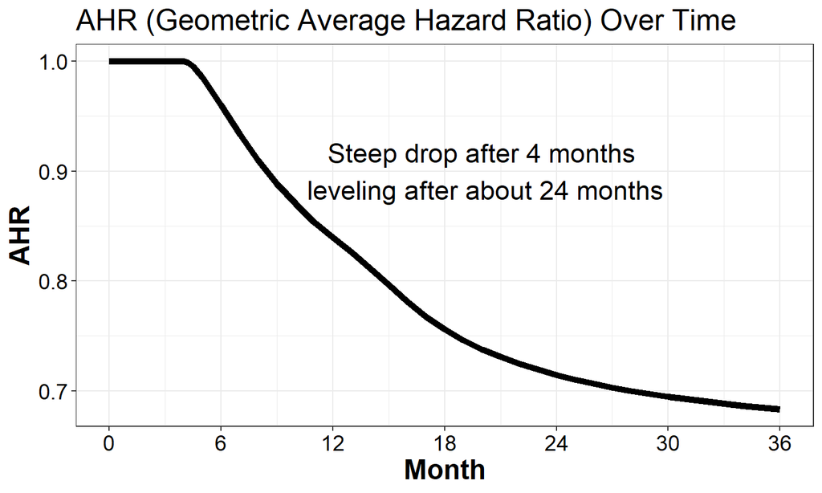

## Power by AHR

- Schoenfeld (1981) approximation works well plugging in average hazard ratio
- Use `gsDesign::nEvents()`

```r
Events <- 332
# if beta is NULL and n= # of events,
# power is computed instead of events required
Power <- gsDesign::nEvents(n = Events, beta = NULL, hr = c(.6, .7, .8))
```

## Power by AHR

Assume 332 events

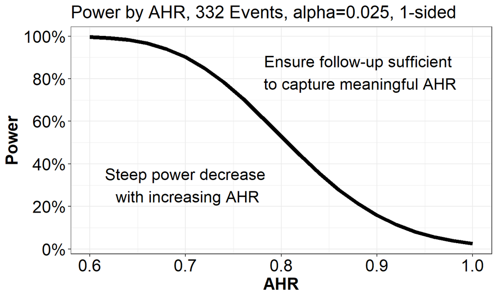

## AHR as estimand

- Some argue this is a bad idea
  - e.g., hazards of hazard ratios (Hernán (2010))
- Pro’s
  - Estimated by Cox regression
  - AHR concept makes more clear what this is
  - Logrank is widely-accepted corresponding test
  - Both asymptotic approximations and simulation supported
    - This includes group sequential design
  - Easy to approximate arbitrary enrollment, failure and dropout patterns
- Cautions
  - No single estimand sufficently describes NPH differences
  - Early interim analysis (futility, efficacy) should anticipate possible reduced effect

## Expected accrual of endpoints

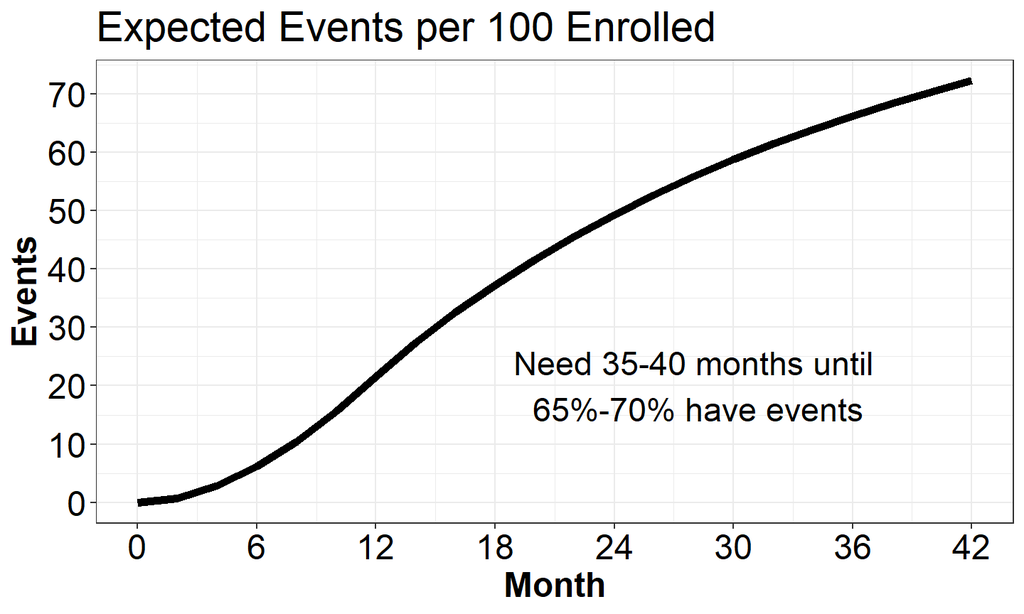

## AHR asymptotic approximation

Used the following code to get AHR and information at specified times:

```r
analysisTimes <- c(12, 20, 28, 36)
sampleSize <- 500
enrollRates <- tibble(Stratum = "All", duration = 12, rate = sampleSize / 12)
failRates <- tibble(
  Stratum = "All",
  duration = c(4, 100),
  failRate = log(2) / 15,
  hr = c(1, .6),
  dropoutRate = 0.001
)
ahr <- gsDesign2::AHR(
  enrollRates = enrollRates,
  failRates = failRates,
  totalDuration = analysisTimes,
  ratio = 1
)
```

## Simulation code considerations

- Many options for cutting data!
  - Time-based
  - Event-based
  - Max of time- and event-based
  - Limit final trial duration
- Note that
  - Code here is detailed, but (hopefully) not complicated
  - AHR changes if event-based
  - Number of events variable if time-based

## Simulation code

```r
# Transform to simPWSurv() format
x <- simfix2simPWSurv(failRates)
nsim <- 10000 # of simulations
# Set up matrix for simulation results
results <- matrix(0, nrow = nsim * 4, ncol = 6)
colnames(results) <- c("Sim", "Analysis", "Events", "beta", "var", "logrank")
ii <- 0 # index for results row
for (sim in 1:nsim) {
  # Simulate a trial
  ds <- simPWSurv(
    n = sampleSize,
    enrollRates = enrollRates,
    failRates = x$failRates,
    dropoutRates = x$dropoutRates
  )
  for (j in seq_along(analysisTimes)) {
    # Cut data at specified analysis times
    # Use cutDataAtCount to cut at event count
    dsc <- ds %>% cutData(analysisTimes[j])
    ii <- ii + 1
    results[ii, 1] <- sim
    results[ii, 2] <- j
    results[ii, 3] <- sum(dsc$event)
    cox <- coxph(Surv(tte, event) ~ Treatment, data = dsc)
    results[ii, 4] <- as.numeric(cox$coefficients)
    results[ii, 5] <- as.numeric(cox$var)
    # Logrank test
    Z <- dsc %>%
      tensurv(txval = "Experimental") %>%
      tenFH(rg = tibble::tibble(rho = 0, gamma = 0))
    results[ii, 6] <- as.numeric(Z$Z)
  }
}
```

## Simulation summary

Simulation summary based on 10k replications

```r
results <- tibble::as_tibble(results)
simsum <- results %>%
  group_by(Analysis) %>%
  summarize(
    AHR = exp(mean(beta)), Events = mean(Events),
    info = 1 / mean(var(beta)), info0 = Events / 4
  )
```

## Comparison of asymptotics vs simulation

Asymptotic Approximation

| Time | AHR | Events | info | info0 |
| --- | --- | --- | --- | --- |
| 12.00 | 0.84 | 107.39 | 26.37 | 26.85 |
| 20.00 | 0.74 | 207.90 | 50.67 | 51.97 |
| 28.00 | 0.70 | 279.10 | 68.23 | 69.78 |
| 36.00 | 0.68 | 331.29 | 81.38 | 82.82 |

10k simulations

| AHR | Events | info | info0 |
| --- | --- | --- | --- |
| 0.84 | 107.16 | 25.48 | 26.79 |
| 0.74 | 207.77 | 49.74 | 51.94 |
| 0.70 | 278.93 | 67.29 | 69.73 |
| 0.68 | 331.13 | 80.11 | 82.78 |

## Distribution of Cox coefficient

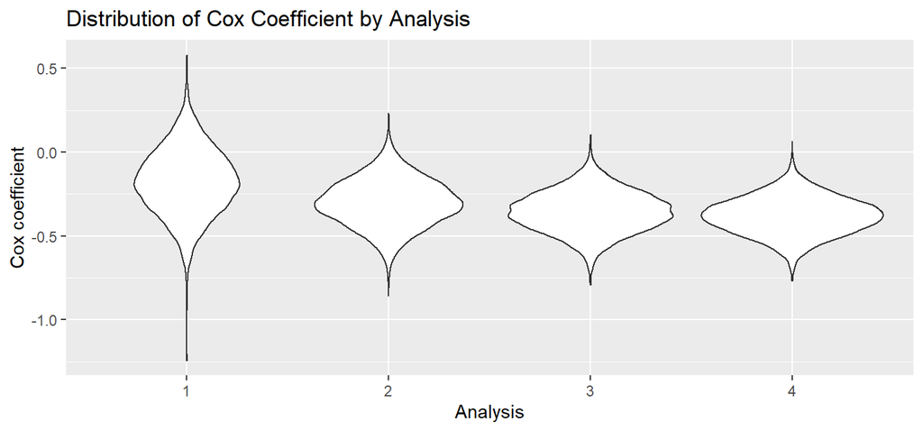

```r
ggplot(results, aes(x = factor(Analysis), y = beta)) +
  geom_violin() +
  ggtitle("Distribution of Cox Coefficient by Analysis") +
  xlab("Analysis") +
  ylab("Cox coefficient")
```

## Variability of results

9 simulations

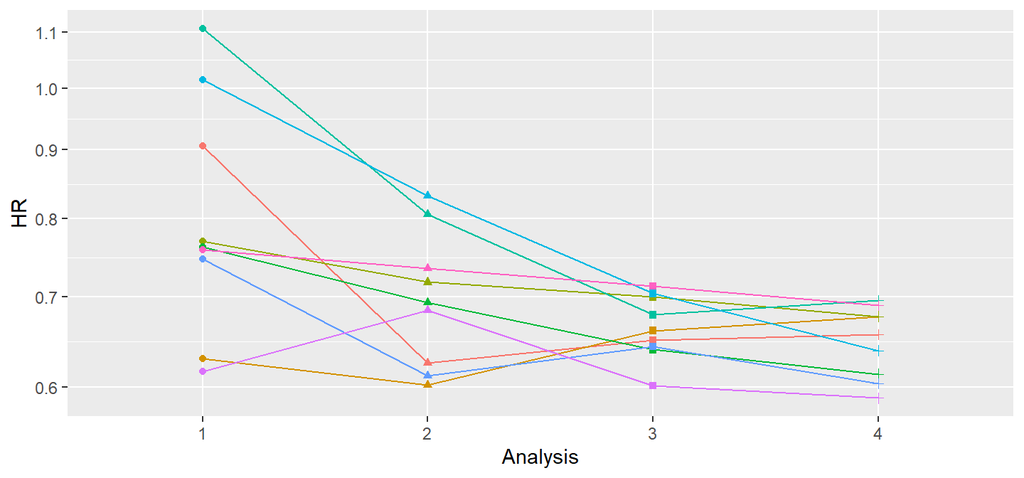

Question: Do you really want to adapt sample size based on an early interim estimate of treatment effect?

## Asymptotic approximation

- Use of Tsiatis (1982) (also extends to weighted logrank)
- Statistical information proportional to expected event counts as in Schoenfeld (1981)
- Natural parameter: \(\log(\hbox{AHR})\)
- Statistical information still proportional to number of events
- Correlation still computed based on statistical information
- Extension of Jennison and Turnbull (2000) calculations to non-constant effect size over time

## Asymptotic distribution simplified

Statistical information at analysis: \(\mathcal{I}_k\), \(1\le k\le K\)

Proportion of final information at analysis \(k\): \(t_k =\mathcal{I}_k / \mathcal{I}_K\)

\[Z_k\sim \hbox{Normal}(\sqrt{\mathcal{I}_k} \theta(t_k),1)\] Multivariate normal with correlations for \(1\le j\le k\le K\):

\[\hbox{Corr}(Z_j,Z_k)=\sqrt{t_j/t_k}\]

## General theory to AHR translation

- Previously, Cox \(\hat\beta\) was shown to be approximately a weighted \(\log(AHR)\)
- How do we translate to extended *canonical form* with \(\theta(t_k)\), \(\mathcal{I_k}\), \(1\le k\le K\)?
  - Assume piecewise model
  - Fix some \(k\) in \(1,2,\ldots,K\)
    - Fix calendar time of analysis \(k\) relative to opening of enrollment; can solve for this if event-based spending fraction desired
    - Compute \(\mathcal{I_k}\) as before based on expected events
    - Compute \(t_k=\mathcal{I}_k/\mathcal{I}_K\)
    - Compute expected Cox coefficient \(\beta\) (\(=\log(AHR)\)) as before and set \(\theta(t_k)=\beta\)
- We now have *canonical form* for the piecewise model

## Group sequential design with spending bounds

## Recalling assumptions

```r
analysisTimes <- c(12, 20, 28, 36)
sampleSize <- 500
```

`enrollRates`

| Stratum | duration | rate |
| --- | --- | --- |
| All | 12 | 41.7 |

`failRates`

| Stratum | duration | failRate | hr | dropoutRate |
| --- | --- | --- | --- | --- |
| All | 4 | 0.046 | 1.0 | 0.001 |
| All | 100 | 0.046 | 0.6 | 0.001 |

## Interim and final timing, effect size, information

`ahr`

| Time | AHR | Events | info | info0 |
| --- | --- | --- | --- | --- |
| 12 | 0.84 | 107.4 | 26.4 | 26.8 |
| 20 | 0.74 | 207.9 | 50.7 | 52.0 |
| 28 | 0.70 | 279.1 | 68.2 | 69.8 |
| 36 | 0.68 | 331.3 | 81.4 | 82.8 |

Information fraction for interim analyses

```
## [1] 0.3241690 0.6275343 0.8424726
```

## One-sided design

## One-sided design with proportional hazards (gsDesign)

```r
PH1sided <- gsDesign::gsSurv( # Derive Group Sequential Design
  k = 4, # Number of analyses (interim + final)
  test.type = 1, # use this for 1-sided testing
  alpha = 0.025, # 1-sided Type I error
  beta = 0.1, # Type II error (1 - power)
  timing = timing, # Information fraction for interims
  sfu = sfLDOF, # O'Brien-Fleming spending approximation
  lambdaC = failRates$failRate, # Piecewise control failure rates
  hr = ahr$AHR[4], # Used final analysis AHR
  eta = failRates$dropoutRate, # Piecewise exponential dropout rates
  gamma = enrollRates$rate, # Relative enrollment
  R = enrollRates$duration, # Duration of piecewise enrollment rates
  S = failRates$duration[1], # Duration of piecewise failure rates (K-1)
  T = max(analysisTimes), # Study duration
  minfup = max(analysisTimes) - sum(enrollRates$duration), # Minimum follow-up
  ratio = 1 # Experimental:Control randomization ratio
)
```

## One-sided design with gsSurv()

| Analysis | Value | Efficacy |
| --- | --- | --- |
| IA 1: 32% | Z | 3.7670 |
| N: 444 | p (1-sided) | 0.0001 |
| Events: 97 | ~HR at bound | 0.4636 |
| Month: 13 | P(Cross) if HR=1 | 0.0001 |
|  | P(Cross) if HR=0.68 | 0.0289 |
| IA 2: 63% | Z | 2.6020 |
| N: 444 | p (1-sided) | 0.0046 |
| Events: 186 | ~HR at bound | 0.6828 |
| Month: 21 | P(Cross) if HR=1 | 0.0047 |
|  | P(Cross) if HR=0.68 | 0.4999 |
| IA 3: 84% | Z | 2.2209 |
| N: 444 | p (1-sided) | 0.0132 |
| Events: 250 | ~HR at bound | 0.7549 |
| Month: 28 | P(Cross) if HR=1 | 0.0146 |
|  | P(Cross) if HR=0.68 | 0.7916 |
| Final | Z | 2.0453 |
| N: 444 | p (1-sided) | 0.0204 |
| Events: 297 | ~HR at bound | 0.7885 |
| Month: 36 | P(Cross) if HR=1 | 0.0250 |
|  | P(Cross) if HR=0.68 | 0.9000 |

## One-sided design with gsSurv()

```r
cat(summary(PH1sided))
```

One-sided group sequential design with 4 analyses, time-to-event outcome with sample size 444 and 297 events required, 90 percent power, 2.5 percent (1-sided) Type I error to detect a hazard ratio of 0.68. Enrollment and total study durations are assumed to be 12 and 36 months, respectively. Efficacy bounds derived using a Lan-DeMets O’Brien-Fleming approximation spending function with none = 1.

## One-sided design with gs_design_ahr()

```r
library(gsdmvn)
# Spending function setup
upar <- list(sf = gsDesign::sfLDOF, total_spend = 0.025)
NPH1sided <- gs_design_ahr(
  enrollRates = enrollRates,
  failRates = failRates,
  ratio = 1, alpha = .025, beta = 0.1,
  # Information fraction not required (but available!)
  analysisTimes = analysisTimes,
  # Function to enable spending bound
  upper = gs_spending_bound,
  # Spending function and parameters used
  upar = list(sf = gsDesign::sfLDOF, total_spend = 0.025),
  # Lower bound fixed at -infinity
  lower = gs_b, # allows input of fixed bound
  # With gs_b, just enter values for bounds
  lpar = rep(-Inf, 4)
)
```

## One-sided design with gs_design_ahr()

| Analysis | Bound | Time | N | Events | Z | Probability | AHR | theta | info | info0 |
| --- | --- | --- | --- | --- | --- | --- | --- | --- | --- | --- |
| 1 | Upper | 12 | 464.3 | 99.7 | 3.7670 | 0.0019 | 0.840 | 0.175 | 24.5 | 24.9 |
| 2 | Upper | 20 | 464.3 | 193.0 | 2.6020 | 0.3024 | 0.738 | 0.304 | 47.0 | 48.3 |
| 3 | Upper | 28 | 464.3 | 259.2 | 2.2209 | 0.7329 | 0.700 | 0.357 | 63.3 | 64.8 |
| 4 | Upper | 36 | 464.3 | 307.6 | 2.0453 | 0.9000 | 0.683 | 0.381 | 75.6 | 76.9 |

- You will want to round up events and sample size!
- Interim boundary crossing probability much lower than with PH bounds
  - IA 2 crossing probability 50% under PH
- Sample size larger than for PH (N=444, 297 events)

## Symmetric bounds

## Symmetric bounds

- Moving on to lower bounds
- Common practice is to use binding upper and lower bounds
- Here we use two one-sided tests for \(\alpha-\)spending
- Upper bound \(b_k(\alpha)\) and lower bound \(a_k(\alpha)= - b_k(\alpha)\) defined so that \[ \begin{align} f(s_k,\alpha)-f(s_{k-1},\alpha) =& P_0(\{Z_{k}\geq b_{k}(\alpha)\}\cap_{j=1}^{k-1}\{-b_{j}(\alpha)< Z_{j}< b_{j}(\alpha)\}\\ =& P_0(\{Z_{k}\le -b_{k}(\alpha)\}\cap_{j=1}^{k-1}\{-b_{j}(\alpha)< Z_{j}< b_{j}(\alpha)\} \end{align} \]

## Symmetric design with gsSurv()

| Analysis | Value | Efficacy | Futility |
| --- | --- | --- | --- |
| IA 1: 32% | Z | 3.7670 | -3.7670 |
| N: 444 | p (1-sided) | 0.0001 | 0.0001 |
| Events: 97 | ~HR at bound | 0.4636 | 2.1569 |
| Month: 13 | P(Cross) if HR=1 | 0.0001 | 0.0001 |
|  | P(Cross) if HR=0.68 | 0.0289 | 0.0000 |
| IA 2: 63% | Z | 2.6020 | -2.6020 |
| N: 444 | p (1-sided) | 0.0046 | 0.0046 |
| Events: 186 | ~HR at bound | 0.6828 | 1.4646 |
| Month: 21 | P(Cross) if HR=1 | 0.0047 | 0.0047 |
|  | P(Cross) if HR=0.68 | 0.4999 | 0.0000 |
| IA 3: 84% | Z | 2.2209 | -2.2209 |
| N: 444 | p (1-sided) | 0.0132 | 0.0132 |
| Events: 250 | ~HR at bound | 0.7549 | 1.3246 |
| Month: 28 | P(Cross) if HR=1 | 0.0146 | 0.0146 |
|  | P(Cross) if HR=0.68 | 0.7916 | 0.0000 |
| Final | Z | 2.0453 | -2.0453 |
| N: 444 | p (1-sided) | 0.0204 | 0.0204 |
| Events: 297 | ~HR at bound | 0.7885 | 1.2682 |
| Month: 36 | P(Cross) if HR=1 | 0.0250 | 0.0250 |
|  | P(Cross) if HR=0.68 | 0.9000 | 0.0000 |

## Symmetric design with gs_design_ahr()

```r
library(gsdmvn)

# Spending function and parameters for both bounds
par <- list(sf = gsDesign::sfLDOF, total_spend = 0.025)
NPHsymmetric <- gs_design_ahr(
  enrollRates = enrollRates,
  failRates = failRates,
  ratio = 1, alpha = .025, beta = 0.1,
  # Information fraction not required (but available!)
  analysisTimes = analysisTimes,
  # Function to enable spending bound
  upper = gs_spending_bound,
  lower = gs_spending_bound,
  # Spending function and parameters used
  upar = par,
  lpar = par,
  binding = TRUE, # set lower bound to binding
  h1_spending = FALSE
)
```

## Symmetric design with gs_design_ahr()

| Analysis | Bound | Time | N | Events | Z | Probability | AHR | theta | info | info0 |
| --- | --- | --- | --- | --- | --- | --- | --- | --- | --- | --- |
| 1 | Upper | 12 | 464.3 | 99.7 | 3.7670 | 0.0019 | 0.840 | 0.175 | 24.5 | 24.9 |
| 2 | Upper | 20 | 464.3 | 193.0 | 2.6020 | 0.3024 | 0.738 | 0.304 | 47.0 | 48.3 |
| 3 | Upper | 28 | 464.3 | 259.2 | 2.2209 | 0.7329 | 0.700 | 0.357 | 63.3 | 64.8 |
| 4 | Upper | 36 | 464.3 | 307.6 | 2.0453 | 0.9000 | 0.683 | 0.381 | 75.6 | 76.9 |
| 1 | Lower | 12 | 464.3 | 99.7 | −3.7670 | 0.0000 | 0.840 | 0.175 | 24.5 | 24.9 |
| 2 | Lower | 20 | 464.3 | 193.0 | −2.6020 | 0.0000 | 0.738 | 0.304 | 47.0 | 48.3 |
| 3 | Lower | 28 | 464.3 | 259.2 | −2.2209 | 0.0000 | 0.700 | 0.357 | 63.3 | 64.8 |
| 4 | Lower | 36 | 464.3 | 307.6 | −2.0453 | 0.0000 | 0.683 | 0.381 | 75.6 | 76.9 |

## Asymmetric bounds

## Asymmetric bounds

- Use non-binding upper bound with spending function \(f_1(s,\alpha)\)
- Set lower boundary crossing boundary under null hypothesis; may assume binding for lower bound with spending function \(f_2(s,\gamma)\) for some chosen \(0 < \gamma \le 1-\alpha\)
- Set bounds to satisfy \[ \begin{align} f_1(s_k,\alpha)-f_1(s_{k-1},\alpha) & = P_0(\{Z_{k}\geq b_{k}(\alpha)\}\cap_{j=1}^{k-1}\{Z_{j}< b_{j}(\alpha)\}\\ f_2(s_k,\gamma)-f_2(s_{k-1},\gamma) & = P_\theta(\{Z_{k}< a_{k}(\gamma)\}\cap_{j=1}^{k-1}\{a_{j}(\gamma)\le Z_{j}< b_{j}(\alpha)\} \end{align} \]

## \(\beta\)-spending bounds

- Use non-binding upper bound with spending function \(f_1(s,\alpha)\)
- Set lower boundary crossing boundary under alternate hypothesis \(\theta(t_k)\) (denoted \(\theta\) below)
- Assume spending function \(f_2(s,\gamma)\) for \(\gamma\) set to Type II error; power \(=1-\gamma\)
- Set bounds to satisfy

\[ \begin{align} f_1(s_k,\alpha)-f_1(s_{k-1},\alpha) &= P_0(\{Z_{k}\geq b_{k}(\alpha)\}\cap_{j=1}^{k-1}\{Z_{j}< b_{j}(\alpha)\}\\ f_2(s_k,\gamma)-f_2(s_{k-1},\gamma) &= P_\theta(\{Z_{k}< a_{k}(\gamma)\}\cap_{j=1}^{k-1}\{a_{j}(\gamma)\le Z_{j}< b_{j}(\alpha)\} \end{align} \] - Generally, sample size set so that \(a_K=b_K\)

## \(\beta\)-spending design with gsSurv()

| Analysis | Value | Efficacy | Futility |
| --- | --- | --- | --- |
| IA 1: 32% | Z | 3.7670 | -0.2503 |
| N: 476 | p (1-sided) | 0.0001 | 0.5988 |
| Events: 104 | ~HR at bound | 0.4767 | 1.0505 |
| Month: 13 | P(Cross) if HR=1 | 0.0001 | 0.4012 |
|  | P(Cross) if HR=0.68 | 0.0338 | 0.0143 |
| IA 2: 63% | Z | 2.6020 | 0.8440 |
| N: 476 | p (1-sided) | 0.0046 | 0.1993 |
| Events: 201 | ~HR at bound | 0.6922 | 0.8875 |
| Month: 21 | P(Cross) if HR=1 | 0.0047 | 0.8103 |
|  | P(Cross) if HR=0.68 | 0.5385 | 0.0393 |
| IA 3: 84% | Z | 2.2209 | 1.5151 |
| N: 476 | p (1-sided) | 0.0132 | 0.0649 |
| Events: 269 | ~HR at bound | 0.7626 | 0.8312 |
| Month: 28 | P(Cross) if HR=1 | 0.0144 | 0.9414 |
|  | P(Cross) if HR=0.68 | 0.8185 | 0.0687 |
| Final | Z | 2.0453 | 2.0453 |
| N: 476 | p (1-sided) | 0.0204 | 0.0204 |
| Events: 319 | ~HR at bound | 0.7953 | 0.7953 |
| Month: 36 | P(Cross) if HR=1 | 0.0225 | 0.9775 |
|  | P(Cross) if HR=0.68 | 0.9000 | 0.1000 |

## \(\beta\)-spending design with gs_design_ahr()

```r
library(gsdmvn)
# Spending function setup
upar <- list(sf = gsDesign::sfLDOF, total_spend = 0.025)
lpar <- list(sf = gsDesign::sfHSD, total_spend = .1, param = -2)
NPHasymmetric <- gs_design_ahr(
  enrollRates = enrollRates,
  failRates = failRates,
  ratio = 1, alpha = .025, beta = 0.1,
  # Information fraction not required (but available!)
  analysisTimes = analysisTimes,
  # Function to enable spending bound
  upper = gs_spending_bound,
  lower = gs_spending_bound,
  # Spending function and parameters used
  upar = upar, lpar = lpar
)
```

## \(\beta\)-spending design with gs_design_ahr()

| Analysis | Bound | Time | N | Events | Z | Probability | AHR | theta | info | info0 |
| --- | --- | --- | --- | --- | --- | --- | --- | --- | --- | --- |
| 1 | Upper | 12 | 501.8 | 107.8 | 3.7670 | 0.0021 | 0.840 | 0.175 | 26.5 | 26.9 |
| 2 | Upper | 20 | 501.8 | 208.6 | 2.6020 | 0.3318 | 0.738 | 0.304 | 50.9 | 52.2 |
| 3 | Upper | 28 | 501.8 | 280.1 | 2.2209 | 0.7660 | 0.700 | 0.357 | 68.5 | 70.0 |
| 4 | Upper | 36 | 501.8 | 332.5 | 2.0453 | 0.9000 | 0.683 | 0.381 | 81.7 | 83.1 |
| 1 | Lower | 12 | 501.8 | 107.8 | −1.2899 | 0.0143 | 0.840 | 0.175 | 26.5 | 26.9 |
| 2 | Lower | 20 | 501.8 | 208.6 | 0.3054 | 0.0387 | 0.738 | 0.304 | 50.9 | 52.2 |
| 3 | Lower | 28 | 501.8 | 280.1 | 1.3340 | 0.0681 | 0.700 | 0.357 | 68.5 | 70.0 |
| 4 | Lower | 36 | 501.8 | 332.5 | 2.0453 | 0.1000 | 0.683 | 0.381 | 81.7 | 83.1 |

## Design with interims at specified times

```r
# Spending function setup
upar <- list(sf = gsDesign::sfLDOF, total_spend = 0.025)
lpar <- c(qnorm(.05), rep(-Inf, 3))
NPHskip <- gs_design_ahr(
  enrollRates = enrollRates,
  failRates = failRates,
  ratio = 1, alpha = .025, beta = 0.1,
  # Information fraction not required (but available!)
  analysisTimes = analysisTimes,
  # Upper spending bound
  upper = gs_spending_bound, upar = upar,
  # Skip first efficacy analysis
  test_upper = c(FALSE, TRUE, TRUE, TRUE),
  # Spending function and parameters used
  lower = gs_b, lpar = lpar
)
```

## Design with interims at specified times

| Analysis | Bound | Time | N | Events | Z | Probability | AHR | theta | info | info0 |
| --- | --- | --- | --- | --- | --- | --- | --- | --- | --- | --- |
| 1 | Lower | 12 | 467.6 | 100.4 | −1.6449 | 0.0060 | 0.840 | 0.175 | 24.7 | 25.1 |
| 2 | Upper | 20 | 467.6 | 194.4 | 2.5999 | 0.3057 | 0.738 | 0.304 | 47.4 | 48.6 |
| 3 | Upper | 28 | 467.6 | 261.0 | 2.2207 | 0.7359 | 0.700 | 0.357 | 63.8 | 65.3 |
| 4 | Upper | 36 | 467.6 | 309.8 | 2.0452 | 0.9000 | 0.683 | 0.381 | 76.1 | 77.5 |

## Review of multiplicity issues

## Type I error

All probabilities are under null hypothesis

- Nominal p-value: probability of rejecting for a specific test conditioning on nothing else
- Repeated p-value: \(\alpha\)-level at which a group sequential test would be rejected at a given analysis for a specific hypothesis
- Sequential p-value: \(\alpha\)-level at which a group sequential test would be rejected for all analyses performed
  - Both sequential and repeated p-values can be performed on interim data
- FWER - Given a set of hypotheses with fixed and/or group sequential designs, the FWER at which an individual hypothesis would be rejected with one of the analyses performed

## Other tests

## Outline

We consider other alternative tests for group sequential design.

- Review fixed design
  - Weighted logrank test
  - MaxCombo test
  - Illustration using [`npsurvSS`](https://cran.r-project.org/package=npsurvSS)
- Group sequential design with weighted logrank test
  - Under a given boundary
  - Boundary calculation
  - Illustration using [`gsdmvn`](https://merck.github.io/gsdmvn/)
- Group sequential design with MaxCombo test
  - Under a given boundary
  - Boundary calculation
  - Illustration using [`gsdmvn`](https://merck.github.io/gsdmvn/)

## Fixed design

For simplicity, we made a few key assumptions.

- Balanced design (1:1 randomization ratio).
- 1-sided test.
- Local alternative: variance under null and alternative are approximately equal.
- Accrual distribution: Piecewise uniform.
- Survival distribution: piecewise exponential.
- Loss to follow-up: exponential.
- No stratification.
- No cure fraction.

The fixed design part largely follows the concept described in Yung and Liu (2019).

## Notation

- \(\alpha\): Type I error
- \(\beta\): Type II error or power (1 - \(\beta\))
- \(z_\alpha\): upper \(\alpha\) percentile of standard normal distribution
- \(z_\beta\): upper \(\beta\) percentile of standard normal distribution

We considered a 1-sided test with type I error at \(\alpha=0.025\) and \(1-\beta=80\%\) power.

```r
z_alpha <- abs(qnorm(0.025))
z_alpha
```

```
## [1] 1.959964
```

```r
z_beta <- abs(qnorm(0.2))
z_beta
```

```
## [1] 0.8416212
```

## Sample size calculation

- \(\theta\): effect size
- \(n\): total sample size
- \(Z\): test statistics is asymptotic normal
  - Under null hypothesis: \(Z \sim \mathcal{N}(0, \sigma_0^2)\)
  - Under alternative hypothesis: \(Z \sim \mathcal{N}(\sqrt{n}\theta, \sigma_1^2)\)

By assuming local alternative, we have

\[\sigma_0^2 \approx \sigma_1^2 = \sigma^2\] In this simplified case, the sample size can be calculated as

\[ n = \frac{4 (z_{\alpha}+z_{\beta})^{2}}{\theta^2} \]

## Examples

- [Two-sample t-test](https://keaven.github.io/gsd-deming/fixed-design.html#two-sample-t-test)
- [Logrank test](https://keaven.github.io/gsd-deming/fixed-design.html#logrank-test)

## Sample size calculation under non-proportional hazards

- https://keaven.github.io/gsd-deming/fixed-design.html#non-proportional-hazards

## Fixed design with weighted logrank test

- [Examples](https://keaven.github.io/gsd-deming/fixed-design.html#weighted-logrank-test)
- [Technical details](https://keaven.github.io/gsd-deming/fixed-design.html#technical-details) are skipped

## Fixed design with MaxCombo test

- [Examples](https://keaven.github.io/gsd-deming/fixed-design.html#maxcombo-test)

## Group sequential design with weighted logrank test

Similar to the fixed design, we can define the test statistics for weighted logrank test using counting process formula

\[ Z_k=\sqrt{\frac{n_{0}+n_{1}}{n_{0}n_{1}}}\int_{0}^{t_k}w(t)\frac{\overline{Y}_{0}(t)\overline{Y}_{1}(t)}{\overline{Y}_{0}(t)+\overline{Y}_{0}(t)}\left\{ \frac{d\overline{N}_{1}(t)}{\overline{Y}_{1}(t)}-\frac{d\overline{N}_{0}(t)}{\overline{Y}_{0}(t)}\right\} \]

Note, the only difference is that the test statistics fixed analysis up to \(t_k\) at \(k\)-th interim analysis

## Group sequential design with weighted logrank test

- [Examples with pre-defined boundary](https://keaven.github.io/gsd-deming/wlr.html#example-scenario)
- [Examples with calculated boundary](https://keaven.github.io/gsd-deming/wlr-boundary.html)
- [Technical details](https://keaven.github.io/gsd-deming/wlr.html#technical-details-1) are skipped

## Group sequential design with MaxCombo test

- [Examples with pre-defined boundary](https://keaven.github.io/gsd-deming/wlr.html#example-scenario)
- [Examples with calculated boundary](https://keaven.github.io/gsd-deming/maxcombo-boundary.html)
- [Technical details](https://keaven.github.io/gsd-deming/maxcombo.html#outline-of-technical-details) are skipped

## Summary

## Where to start for NPH?

- Understand your control group
  - Get *simple* assumptions to approximate published results?
- Understand AHR
  - Consider treatment effect that is clinically meaningful, but conservative
  - Consider a treatment effect delay that is *intermediate*
  - Understand likely enrollment pattern and dropout rate
  - Plot AHR, underlying survival differences and expected accrual of patients and events

## Where to start for NPH?

- Follow-up (trial duration)
  - Get to *good* part of AHR could (it will plateau under above assumptions)
  - Ensure follow-up long enough to ensure *tail* characterization
  - Require both minimum follow-up and sufficient events for final analysis

## Simplest design approach

- Start with AHR from above evaluation
- Design under proportional hazards assuming constant AHR
- Ensure early futility bounds are not too aggressive
  - No futility (risk that data monitoring committee will overrule)
  - \(\beta\)-spending: be conservative for early bounds
  - Asymmetric 2-sided test; e.g., Pocock-like bound with *moderate* total boundary crossing probability
- Efficacy bounds: O’Brien-Fleming always acceptable to regulators
- This is easy to do with gsDesign Shiny app!

## More advanced needs: **gsdmvn**

- For primary analysis, may wish to stick with logrank test
  - Well-accepted by regulatory agencies
- Futility bounds and power take into account changing effect over time
  - NPH will also impact expected timing of analyses
- More easily allows interim timing based on calendar time
- More options for setting boundaries
  - Fixed futility bounds
  - Haybittle-Peto bounds
  - Futility or efficacy bounds can be eliminated from selected analyses

## Less conventional tests

- RMST has been heavily promoted
  - For delayed effect, power is generally no better than logrank
  - However, some advocate these for primary analysis
- Sensitivity analyses with better power assuming delayed effect
  - Weighted logrank with FH(0, 0.5) or Magirr-Burman test
  - MaxCombo test at final analysis only
- There can be substantial power gains

## Thank you!

- Feedback and questions are welcome!
- May wish to submit by issues at GitHub repositories, but e-mail also OK.

## Thank you

**Email:** keaven_anderson@merck.com

## References

[1] Scharfstein, D. O., Tsiatis, A. A. and Robins, J. M. (1997). Semiparametric efficiency and its implication on the design and analysis of group-sequential studies. *Journal of the American Statistical Association* **92** 1342–50.

[2] Jennison, C. and Turnbull, B. W. (2000). *Group sequential methods with applications to clinical trials*. Chapman; Hall/CRC, Boca Raton, FL.

[3] Lachin, J. M. and Foulkes, M. A. (1986). Evaluation of sample size and power for analyses of survival with allowance for nonuniform patient entry, losses to follow-up, noncompliance, and stratification. *Biometrics* **42** 507–19.

[4] Schoenfeld, D. (1981). The asymptotic properties of nonparametric tests for comparing survival distributions. *Biometrika* **68** 316–9.

[5] Mukhopadhyay, P., Huang, W., Metcalfe, P., Öhrn, F., Jenner, M. and Stone, A. (2020). Statistical and practical considerations in designing of immuno-oncology trials. *Journal of Biopharmaceutical Statistics* 1–7.

[6] Yung, G. and Liu, Y. (2020). Sample size and power for the weighted log-rank test and kaplan-meier based tests with allowance for nonproportional hazards. *Biometrics* **76** 939–50.

[7] Karrison, T. G. and others. (2016). Versatile tests for comparing survival curves based on weighted log-rank statistics. *Stata Journal* **16** 678–90.

[8] Kim, K. and Tsiatis, A. A. (1990). Study duration for clinical trials with survival response and early stopping rule. *Biometrics* 81–92.

[9] Lan, K. K. G. and DeMets, D. L. (1983). Discrete sequential boundaries for clinical trials. *Biometrika* **70** 659–63.

[10] Haybittle, J. (1971). Repeated assessment of results in clinical trials of cancer treatment. *The British Journal of Radiology* **44** 793–7.

[11] Peto, R., Pike, Mc., Armitage, P., Breslow, N. E., Cox, D., Howard, S., Mantel, N., McPherson, K., Peto, J. and Smith, P. (1977). Design and analysis of randomized clinical trials requiring prolonged observation of each patient. II. Analysis and examples. *British Journal of Cancer* **35** 1–39.

[12] Wang, S. K. and Tsiatis, A. A. (1987). Approximately optimal one-parameter boundaries for group sequential trials. *Biometrics* 193–9.

[13] Pocock, S. J. (1977). Group sequential methods in the design and analysis of clinical trials. *Biometrika* **64** 191–9.

[14] O’Brien, P. C. and Fleming, T. R. (1979). A multiple testing procedure for clinical trials. *Biometrics* 549–56.

[15] Slud, E. and Wei, L. (1982). Two-sample repeated significance tests based on the modified wilcoxon statistic. *Journal of the American Statistical Association* **77** 862–8.

[16] Fleming, T. R., Harrington, D. P. and O’Brien, P. C. (1984). Designs for group sequential tests. *Controlled Clinical Trials* **5** 348–61.

[17] Lan, K. K. G. and DeMets, D. L. (1989). Group sequential procedures: Calendar versus information time. *Statistics in Medicine* **8** 1191–8.

[18] Gandhi, L., Rodrı́guez-Abreu, D., Gadgeel, S., Esteban, E., Felip, E., De Angelis, F., Domine, M., Clingan, P., Hochmair, M. J., Powell, S. F. and others. (2018). Pembrolizumab plus chemotherapy in metastatic non–small-cell lung cancer. *New England Journal of Medicine* **378** 2078–92.

[19] Maurer, W. and Bretz, F. (2013). Multiple testing in group sequential trials using graphical approaches. *Statistics in Biopharmaceutical Research* **5** 311–20.

[20] Downs, J. R., Beere, P. A., Whitney, E., Clearfield, M., Weis, S., Rochen, J., Stein, E. A., Shapiro, D. R., Langendorfer, A. and Gotto Jr, A. M. (1997). Design & rationale of the air force/texas coronary atherosclerosis prevention study (AFCAPS/TexCAPS). *The American Journal of Cardiology* **80** 287–93.

[21] Downs, J. R., Clearfield, M., Weis, S., Whitney, E., Shapiro, D. R., Beere, P. A., Langendorfer, A., Stein, E. A., Kruyer, W., Gotto Jr, A. M. and others. (1998). Primary prevention of acute coronary events with lovastatin in men and women with average cholesterol levels: Results of AFCAPS/TexCAPS. *Journal of the American Medical Association* **279** 1615–22.

[22] Hwang, I. K., Shih, W. J. and De Cani, J. S. (1990). Group sequential designs using a family of type i error probability spending functions. *Statistics in Medicine* **9** 1439–45.

[23] White, W. B., Cannon, C. P., Heller, S. R., Nissen, S. E., Bergenstal, R. M., Bakris, G. L., Perez, A. T., Fleck, P. R., Mehta, C. R., Kupfer, S. and others. (2013). Alogliptin after acute coronary syndrome in patients with type 2 diabetes. *New England Journal of Medicine* **369** 1327–35.

[24] White, W. B., Bakris, G. L., Bergenstal, R. M., Cannon, C. P., Cushman, W. C., Fleck, P., Heller, S., Mehta, C., Nissen, S. E., Perez, A. and others. (2011). EXamination of cArdiovascular outcoMes with alogliptIN versus standard of carE in patients with type 2 diabetes mellitus and acute coronary syndrome (EXAMINE): A cardiovascular safety study of the dipeptidyl peptidase 4 inhibitor alogliptin in patients with type 2 diabetes with acute coronary syndrome. *American Heart Journal* **162** 620–6.

[25] Cohen, E. E., Soulières, D., Le Tourneau, C., Dinis, J., Licitra, L., Ahn, M.-J., Soria, A., Machiels, J.-P., Mach, N., Mehra, R. and others. (2019). Pembrolizumab versus methotrexate, docetaxel, or cetuximab for recurrent or metastatic head-and-neck squamous cell carcinoma (KEYNOTE-040): A randomised, open-label, phase 3 study. *The Lancet* **393** 156–67.

[26] Miettinen, T. A., Pyörälä, K., Olsson, A. G., Musliner, T. A., Cook, T. J., Faergeman, O., Berg, K., Pedersen, T., Kjekshus, J. and Group, for the S. S. S. (1997). Cholesterol-lowering therapy in women and elderly patients with myocardial infarction or angina pectoris: Findings from the scandinavian simvastatin survival study (4S). *Circulation* **96** 4211–8.

[27] Shitara, K., Özgüroğlu, M., Bang, Y.-J., Di Bartolomeo, M., Mandalà, M., Ryu, M.-H., Fornaro, L., Olesiński, T., Caglevic, C., Chung, H. C. and others. (2018). Pembrolizumab versus paclitaxel for previously treated, advanced gastric or gastro-oesophageal junction cancer (KEYNOTE-061): A randomised, open-label, controlled, phase 3 trial. *The Lancet* **392** 123–33.

[28] Hernán, M. A. (2010). The hazards of hazard ratios. *Epidemiology* **21** 13.

[29] Tsiatis, A. A. (1982). Repeated significance testing for a general class of statistics use in censored survival analysis. *Journal of the American Statistical Association* **77** 855–61.

[30] Yung, G. and Liu, Y. (2019). Sample size and power for the weighted log-rank test and kaplan-meier based tests with allowance for nonproportional hazards. *Biometrics*.